# Game Theory

Austin Halvorsen

3/29/2019

## Rock Paper Scissors

In this simple game, each player takes their turn ‘throwing’ either a rock (closed fist), paper (open hand), or scissors (two fingers extended). Now, I’m sure you are all familiar with the rules of the game, but we all know that rock beats scissors, scissors wins paper, and (*somehow*) paper covers rock.

Now, right off the bat, it would seem that this game is all strictly random based. Each person has a 33% chance of winning, losing, or being tied with their opponent. So how could we make a smart AI that can out wit random chance?

### Week 12

#### Requirement 1

**Determine all possible choices that your AI will need to make while playing your selected game.**

In the game, there are really only three moves that a computer could make at any given time, and since they are only thrown at random, the computer could only choose rock, paper, or scissors.

What the computer needs to understand is what they need to do in order to win. So we tell the AI that:

- Rock > Scissors
- Scissors > Paper
- Paper > Rock

This lays the foundation for how to win while playing the game, but we also need to explain all the combinations as well.

For this we have:

| Player Move | Result | AI Move |
| --- | --- | --- |
| Rock | Draw | Rock |
| Paper | —W—> | Scissors |
| Scissors | <—W— | Paper |
| Rock | —W—> | Paper |
| Paper | <—W— | Rock |
| Scissors | Draw | Scissors |
| Rock | <—W— | Scissors |
| Paper | Draw | Paper |
| Scissors | –W—> | Rock |

With this table in mind, we can see that the computer has $\frac39$ chances of a draw, $\frac39$ chances at a win, and $\frac39$ chances at a loss.

The AI will have to account and adjust for these probabilities as it plays the game.

#### Requirement 2

**Understand the logic or calculations that your AI will need to preform to make the best decisions possible for each choice it is presented with.**

So if the game is based more in random chance than strategy, is there a way to create an AI that can outsmart a person? Well, humans are rather [predictably irrational](https://www.amazon.com/Predictably-Irrational-Revised-Expanded-Decisions/dp/0061353248) and tend to repeat things that bring success or change patterns that cause them to lose. In essence, we need to make an AI that exploits these tendencies in humans to try and beat them.

For example, if a person wins playing rock, they are more likely to throw rock. We need to tell our AI then, to play paper to beat rock. On the other end, lets say a person lost by playing scissors, meaning our AI just played rock. Chances are that our person is going to play paper so we need to play scissors.

This is a very elementary approach to this problem and their are countless mathematical approaches on how to increase the chance of the computer winning. In efforts to keep this inside of my realm of programming, we are going to keep is simple using those two rules.

#### Requirement 3

For this model, the game with be simple and statistically based. It will make decisions intelligently and try to predict players moves based on logic that is programmed in based on the rules given above. Something that I was able to learn throughout my research is that it is best to give simple rules and then let the computer figure it out through trial and error. I am not sure if my programming is quite there, but I am going to see what I can do!

#### Sources

[Win at Rock-Paper-Scissors Every Time, With Math](https://motherboard.vice.com/en_us/article/gvym4x/game-theory-rock-paper-scissors)

[Why Winning in Rock-Paper-Scissors (and in Life) Isn’t Everything](https://www.quantamagazine.org/the-game-theory-math-behind-rock-paper-scissors-20180402/)

[Game Theory 101](http://gametheory101.com/courses/game-theory-101/rock-paper-scissors/)

### Week 13

#### Requirement 1

**Begin programming your AI. There is no criteria on what language or tool you use to develop in.**

For this example, we need to program the computer to what makes a win, tie or loss. In the following segment of code, we will list all nine potential moves for both sides and all the possible outcomes. This will help us establish some strategy and models that we can give the computer to help it make different decisions during gameplay.

```r
rps = function(move){
  options = c("rock", "paper", "scissors")
  ai_move = sample(options, size = 1)

  if(move == "rock" & ai_move == "rock"){
    names(ai_move) = "tie"
  }else
    if(move == "rock" & ai_move == "scissors"){
      names(ai_move) = "loss"
    }else
      if(move == "rock" & ai_move == "paper"){
        names(ai_move) = "win"
      }else
        if(move == "paper" & ai_move == "paper"){
          names(ai_move) = "tie"
        }else
          if(move == "paper" & ai_move == "scissors"){
            names(ai_move) = "win"
          }else
            if(move == "paper" & ai_move == "rock"){
              names(ai_move) = "loss"
            }else
              if(move == "scissors" & ai_move == "scissors"){
                names(ai_move) = "tie"
              }else
                if(move == "scissors" & ai_move == "rock"){
                  names(ai_move) = "win"
                }else
                  if(move == "scissors" & ai_move == "paper"){
                    names(ai_move) = "loss"
                  }
  return(ai_move)
}
```

With the basic rules programmed, the next step is to create a vector of human moves that would represent someone randomly picking between the three options.

To do this, R has a function that will sample from a selection, in our case, the moves, and then add that sample to a new vector.

```r
moves = c("rock", "paper", "scissors")
humanMoves = sample(moves, size = 100, replace = TRUE)

pander::pander(table(humanMoves))
```

| paper | rock | scissors |
| --- | --- | --- |
| 37 | 32 | 31 |

Our sample seems to lean towards one option of the others, it will be interesting to see if our ai will be able to hone in on this pattern and beat the human moves.

```r
rps.random=function(move){
  ai_moves = vector("character")

  for(i in 1:length(move)){
    ai_move=rps(move[i])
    ai_moves = append(ai_moves,ai_move, after = length(ai_moves))
  }
  winrate.random = mean(names(ai_moves) == "win")
  return(winrate.random)
  #return(ai_moves)
}
results.random = rps.random(humanMoves)
```

### Week 14

#### Requirement 1

**Finish up your AI model.**

A popular method to win at rock paper scissors is use the move your oppenent just used to beat you, then continually use the move you lost against or the move you used to win, to beat your opponent. In this method I want to implement, I want to use memory to detect some patterns in the human (random moves) to see if we can make the computer smarter by identifying these patterns. Follow along in the comments to see what each line of code does.

```r
# For this function, we are going to see if the AI can predict the move of the human based on the humans previous moves.

rps.win = function(priormove){

  if(priormove == "rock"){
    aiMove = "paper"
  }else
    if(priormove == "paper"){
      aiMove = "scissors"
    }else
      if(priormove == "scissors"){
        aiMove = "rock"
      }
  return(aiMove)
}

# We are going to restablish the rules of the game to make sure that we are using the correct logic

rpsSmart = function(AiMove,move){

  if(identical(AiMove,move)){
    result.smart = "tie"
  }else
    if(AiMove == "rock" & move == "paper" | AiMove == "paper" & move == "scissors" | AiMove == "scissors" & move == "rock"){
      result.smart = "loss"
    }else{
      result.smart = "win"
    }
  return(result.smart)
}

rps.smart = function(move){
  AiSmartMoves = vector("character")
  thelength = length(move)

  # Since there is no 'memory' we are using going to have the computer throw random moves first ten moves
  for(i in 1:10){

    AiSmart = rps(move[i])
    AiSmartMoves = append(AiSmartMoves,
                          AiSmart,
                          after = length(AiSmartMoves))
  }

  for(i in 11:thelength){
    last2human = move[(i-2):(i-1)]

    showedup = F
    move.to.beat = ""

    # Now, we are going to loop
    # through the vector to see
    # previous human moves for
    # the AI to use

    for(j in 1:(i-3)){
      testmoves = move[j:j+1]
      if(testmoves == last2human){
        showedup = T
        move.to.beat = move[j+2]
      }
    }
    # If the right move appeared, we will throw the move to beat the move thrown
    if(showedup == T){
      AiSmart = rps.win(move.to.beat)
      names(AiSmart) = rpsSmart(AiSmart,move[i])
    }else{
      # Otherwise, we are just going to throw a random move
      AiSmart = rps(move[i])
      names(AiSmart) = rpsSmart(AiSmart,move[i])
    }
    AiSmartMoves = append(AiSmartMoves,AiSmart, after = length(AiSmartMoves))
  }
  memWinAiRate = mean(names(AiSmartMoves) == "win")
  return(memWinAiRate)
}

results.smart = rps.smart(humanMoves)
```

#### Graphing the Win rate

To see if there was an effectiveness in the winrate of these two stragetgies, I have compute the average win percentage for both. Take a look at the chart:

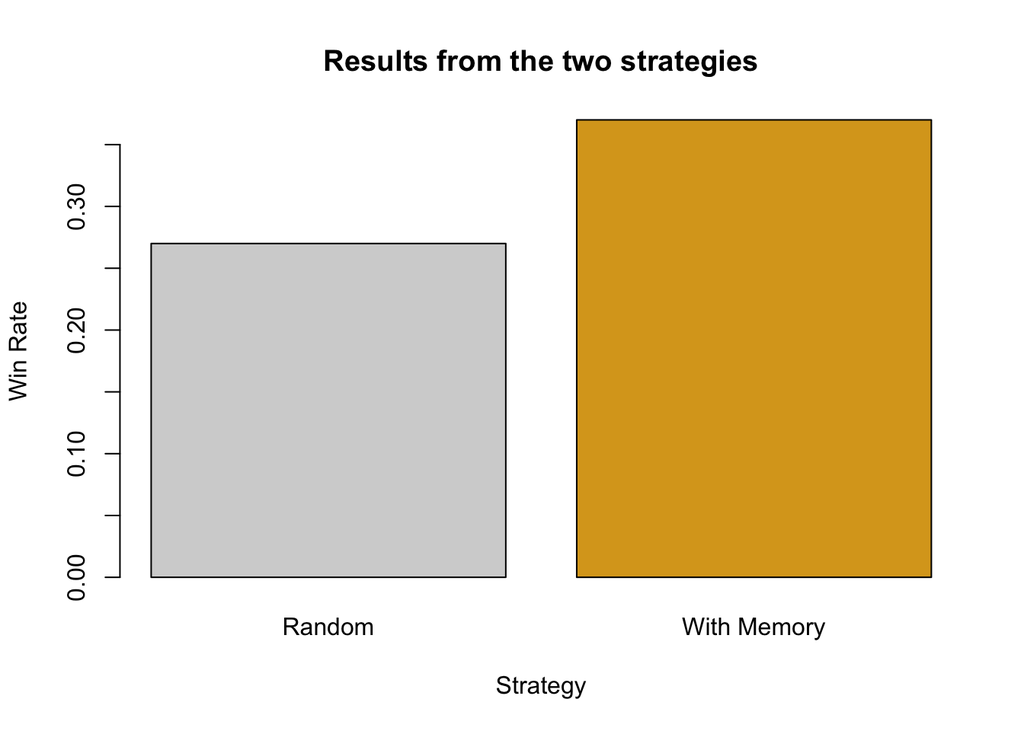

```r
compare.results = c(results.random, results.smart)

barplot(compare.results, col = c("lightgrey", "goldenrod"),
        names.arg=c("Random", "With Memory"),
        xlab="Strategy", ylab="Win Rate", main="Results from the two strategies")
```

#### Results

Overall, our results are really interesting. We see that the smart memory strategy has an advantage over just random throws, but it would be interesting to compare more models and see if we could make this even more reliable. Obviously, in any game of randomeness, there is always going to be luck involved, but it is interesting to think that there is a way that we could beat the randomness that we see.

Even more interestingly, occasially we can observe that random throws can beat the memory model. It would be fascinating to to see if those examples could be used to bolster our model and make it even better at beating random games.

Thanks for reading through this report. I hope that it made some sense and you were able to glean some informative things from it!